# A Tutorial Introduction to R

## Matrices and arrays

### Creating matrices

A matrix is a two-dimensional array of items. Most straightforwardly, we can create a matrix by specifying the number of rows and columns, and specifying the entries. For example

```r
X <- matrix(c(1,2,3,4,5,6),nrow=2,ncol=3); X
```

**output**

```
     [,1] [,2] [,3]
[1,]    1    3    5
[2,]    2    4    6
```

takes the values 1 to 6 and reshapes them into a 2 by 3 matrix. Note that the values in the data vector are put into the matrix *column-wise*, by default. You can change this by using the optional parameter `byrow`:

```r
A <- matrix(1:9,nrow=3,ncol=3,byrow=TRUE); A
```

**output**

```
     [,1] [,2] [,3]
[1,]    1    2    3
[2,]    4    5    6
[3,]    7    8    9
```

**R** will re-cycle through entries in the data vector, if need be, to fill a matrix of the specified size. So for example

```r
matrix(1,nrow=50,ncol=50)
```

creates a $50{\times}50$ matrix, every entry of which is $1$.

##### Exercise

Use a command of the form `X <- matrix(v,nrow=2,ncol=4)` where `v` is a data vector, to create the following matrix `X`:

**output**

```
     [,1] [,2] [,3] [,4]
[1,]    1    1    1    1
[2,]    2    2    2    2
```

**R** will also cause a matrix to behave like a vector whenever it makes sense: for example `sum(X)` above is 12.

##### Exercise

Use `rnorm` and `matrix` to create a $5{\times}7$ matrix of Gaussian random numbers with mean 1 and standard deviation 2.

Another useful function for creating matrices is `diag`. `diag(v,n)` creates an $n{\times}n$ matrix with data vector $v$ on its diagonal. So for example `diag(1,5)` creates the $5{\times}5$ *identity matrix*, which has 1s on the diagonal and 0 everywhere else.

Finally, one can use the `data.entry` function. This function can only edit existing matrices, but for example (try this now!)

```r
A <- matrix(0,3,4)
data.entry(A)
```

will create `A` as a $3{\times}4$ matrix, and then call up a spreadsheet-like interface in which the values can be edited directly. You can further modify `A` with the same primitive interface, using `fix`.

Some important functions for creating and working with matrices.

| **R** code | purpose |
| --- | --- |
| `matrix(v,nrow=m,ncol=n)` | $m \times n$ matrix using the values in `v` |
| `t(A)` | transpose (exchange rows and columns) of matrix `A` |
| `dim(X)` | dimensions of matrix X. `dim(X)[1]`=# rows, `dim(X)[2]`=# columns |
| `data.entry(A)` | call up a spreadsheet-like interface to edit the values in `A` |
| `diag(v,n)` | diagonal $n \times n$ matrix with $v$ on diagonal, 0 elsewhere (`v` is 1 by default, so `diag(n)` gives an $n \times n$ identity matrix) |
| `cbind(a,b,c,...)` | combine compatible objects by attaching them along columns |
| `rbind(a,b,c,...)` | combine compatible objects by attaching them along rows |
| `as.matrix(x)` | convert an object of some other type to a matrix, if possible |
| `outer(v,w)` | “outer product” of vectors `v`, `w`: the matrix whose $(i,j)$-th element is `v[i]*w[j]` |

Many of these functions have additional optional arguments; use the help system for full details.

### `cbind` and `rbind`

If their sizes match, vectors can be combined to form matrices, and matrices can be combined with vectors or matrices to form other matrices. The functions that do this are `cbind` and `rbind`.

`cbind` binds together columns of two objects. One thing it can do is put vectors together to form a matrix:

```r
C <- cbind(1:3,4:6,5:7); C
```

**output**

```
     [,1] [,2] [,3]
[1,]    1    4    5
[2,]    2    5    6
[3,]    3    6    7
```

Remember that **R** interprets vectors as row or column vectors according to what you’re doing with them. Here it treats them as column vectors so that columns exist to be bound together. On the other hand,

```r
D <- rbind(1:3,4:6); D
```

**output**

```
     [,1] [,2] [,3]
[1,]    1    2    3
[2,]    4    5    6
```

treats them as rows. Now we have two matrices that can be combined.

##### Exercise

Verify that `rbind(C,D)` works, `cbind(C,C)` works, but `cbind(C,D)` doesn’t. Why not?

### Matrix indexing

Matrix indexing is like vector indexing except that you have to specify both the row and column, or range of rows and columns. For example `z <- A[2,3]` sets `z` equal to 6, which is the (2<sup>nd</sup> row, 3<sup>rd</sup> column) entry of the matrix **A** that you recently created, and

```r
A[2,2:3];
```

**output**

```
[1] 5 6
```

```r
B <- A[2:3,1:2]; B
```

**output**

```
     [,1] [,2]
[1,]    4    5
[2,]    7    8
```

There is an easy shortcut to extract entire rows or columns: leave out the limits, leaving a blank before or after the comma.

```r
first.row <- A[1,]; first.row
```

**output**

```
[1] 1 2 3
```

```r
second.column <- A[,2]; second.column;
```

**output**

```
[1] 2 5 8
```

(What does `A[,]` do?)

As with vectors, indexing also works in reverse for assigning values to matrix entries. For example,

```r
A[1,1] <- 12; A
```

**output**

```
     [,1] [,2] [,3]
[1,]   12    2    3
[2,]    4    5    6
[3,]    7    8    9
```

The same can be done with blocks, rows, or columns, for example

```r
A[1,] <- c(2,4,5); A
```

**output**

```
     [,1] [,2] [,3]
[1,]    2    4    5
[2,]    4    5    6
[3,]    7    8    9
```

If you use `which()` on a matrix, **R** will normally treat the matrix as a vector—so for example `which(A==8)` will give the answer 6 (can you see why?). However, `which()` does have an option that will treat its argument as a matrix:

```r
which(A>=8,arr.ind=TRUE)
```

**output**

```
     row col
[1,]   3   2
[2,]   3   3
```

## Arrays

The generalization of the matrix to more (or less) than 2 dimensions is the array. In fact, in **R** , a matrix is nothing other than a 2-dimensional array. How does **R** store arrays? In the simplest possible way: an array is just a vector plus information on the dimensions of the array. Most straightforwardly, we can create an array from a vector:

```r
X <- array(1:24,dim=c(3,4,2)); X
```

**output**

```
, , 1

     [,1] [,2] [,3] [,4]
[1,]    1    4    7   10
[2,]    2    5    8   11
[3,]    3    6    9   12

, , 2

     [,1] [,2] [,3] [,4]
[1,]   13   16   19   22
[2,]   14   17   20   23
[3,]   15   18   21   24
```

Note, again, that the arrays are filled in a particular order: the first dimension first, then the second, and so on. A one-dimensional array is subtly different from a vector:

```r
y <- 1:5; y
```

**output**

```
[1] 1 2 3 4 5
```

```r
z <- array(1:5,dim=5); z
```

**output**

```
[1] 1 2 3 4 5
```

```r
y==z
```

**output**

```
[1] TRUE TRUE TRUE TRUE TRUE
```

```r
identical(y,z)
```

**output**

```
[1] FALSE
```

```r
dim(y)
```

[output not shown]

**output**

```r
dim(z)
```

**output**

```
[1] 5
```

##### Exercise

What happens when we set the dimension attribute on a vector? For example:

```r
x <- seq(1,27)
dim(x) <- c(3,9)
is.array(x)
is.matrix(x)
```

Make sure you understand the above.

## Factors

For dealing with measurements on the nominal and ordinal scales (Stevens 1946), **R** provides vectors of type *factor*. A factor is a variable that can take one of a finite number of distinct *levels*. To construct a factor, we can apply the `factor` function to a vector of any class:

```r
x <- rep(c(1,2),each=3); factor(x)
```

**output**

```
[1] 1 1 1 2 2 2
Levels: 1 2
```

```r
trochee <- c("jetpack","ferret","pizza","lawyer")
trochee <- factor(trochee); trochee
```

**output**

```
[1] jetpack ferret  pizza   lawyer
Levels: ferret jetpack lawyer pizza
```

By default, `factor` sets the levels to the unique set of values taken by the vector. To modify that behavior, there is the `levels` argument:

```r
factor(trochee,levels=c("ferret","pizza","cowboy","scrapple"))
```

**output**

```
[1] <NA>   ferret pizza  <NA>
Levels: ferret pizza cowboy scrapple
```

Note that the order of the levels is arbitrary, in keeping with the fact that the only operation permissible on the nominal scale is the test for equality. In particular, the factors created with the `factor` command are un-ordered: there is no sense in which we can ask whether, e.g., `ferret < cowboy`.

To represent variables measured on the ordinal scale, **R** provides *ordered factors*, constructed via the `ordered` function. An ordered factor is just like an un-ordered factor except that the order of the levels matters:

```r
x <- ordered(sample(x=letters,size=22,replace=TRUE)); x
```

**output**

```
 [1] z m u p a g c d b n x d g n w l c t z p b x
14 Levels: a < b < c < d < g < l < m < n < p < t < ... < z
```

Here, we’ve relied on `ordered`’s default behavior, which is to put the levels in alphabetical order. It’s typically safer to specify explicitly what order we want:

```r
x <- ordered(x,levels=rev(letters))
x[1:5] < x[18:22]
```

**output**

```
[1]  TRUE FALSE  TRUE  TRUE FALSE
```

##### Exercise

Look up the documentation on the `sample` function used above.

##### Exercise

Can I make a matrix or an array out of a factor variable?

##### Exercise

What is the internal representation of factors in **R** ? Try converting factors to integers using `as.integer`. Try converting an integer vector to a factor using `factor`.

## Lists

While vectors and matrices may seem familiar, lists may be new to you. Vectors and matrices have to contain elements that are all the same type: lists in **R** can contain anything—vectors, matrices, other lists, arbitrary objects. Indexing is a little different too: use `[[ ]]` to extract an element of a list by number or name or `$` to extract an element by name (only). Given a list like this:

```r
L <- list(A=x,B=trochee,C=c("a","b","c"))
```

Then `L$A`, `L[["A"]]`, and `L[[1]]` will each return the first element of the list. To extract a sublist, use the ordinary single square brackets: `[]`:

```r
L[c("B","C")]
```

**output**

```
$B
[1] jetpack ferret  pizza   lawyer
Levels: ferret jetpack lawyer pizza

$C
[1] "a" "b" "c"
```

## Data frames

Vectors, matrices, and lists of one sort or another are found in just about every programming language. The *data frame* structure is (or was last time I checked) unique to **R** , and is central to many of **R** ’s useful data-analysis features. It’s very natural to want to store data in vectors and matrices. Thus, in the example above, we stored measurements of two variables ($r_\text{max}$ and light level) in vectors. This was done in such a way that the observations of the first replicate were stored in the first element of each vector, the second in the second, and so on. To explicitly bind together observations corresponding to the same replicate, we might join the two vectors into a matrix using `cbind`. In the resulting data structure, each row would correspond to an observation, each column to a variable. This is possible, however, only because both variables are of the same type: they’re both numerical. More commonly, a data set is made up of several different kinds of variables. The data frame is **R** ’s solution to this problem.

Data frames are a hybrid of lists and vectors. Internally, they are a list of vectors which can be of different types but must all be the same length. However, they behave somewhat like matrices, in that you can do most things to them that you can do with matrices. You can index them either the way you would index a list, using `[[ ]]` or `$`—where each variable is a different item in the list—or the way you would index a matrix.  
You can turn a data frame into a matrix (using `as.matrix()`, but only if all variables are of the same class) and a matrix into a data frame (using `as.data.frame()`).

When data are read into **R** from an external file using one of the `read.xxx` commands (`read.csv`, `read.table`, `read.xls`, etc.), the object that is created is a data frame.

```r
data.url <- "https://kingaa.github.io/R_Tutorial/data/ChlorellaGrowth.csv"
dat <- read.csv(data.url,comment.char='#')
dat
```

**output**

```
 light rmax
    20 1.73
    20 1.65
    20 2.02
    20 1.89
    21 2.61
    24 1.36
    44 2.37
    60 2.08
    90 2.69
    94 2.32
   101 3.67
```

##### Exercise

Download the `hurricanes.csv` file from the tutorial website: https://kingaa.github.io/R_Tutorial/hurricanes.csv. Examine the resulting data frame by printing it and using the `str` command. Note the class type of each variable.

# Probability distributions in R

**R** contains a great deal of distilled knowledge about probability distributions. In particular, for each of a large class of important distributions, methods to compute probability distribution functions (p.d.f., i.e., density or mass functions), cumulative distribution functions (c.d.f.), and quantile functions are available, as are methods for simulating these distributions (i.e., drawing random deviates with the desired distribution). Conveniently, these are all named using the same scheme, as shown in the following table.

Functions for working with probability distributions.

| `dxxx(x, ...)` | probability distribution function |
| --- | --- |
| `pxxx(q, ...)` | cumulative distribution function |
| `qxxx(p, ...)` | quantile function (i.e., inverse of `pxxx`) |
| `rxxx(n, ...)` | simulator |

In the above `xxx` stands for the abbreviated name of the specific distribution (the “**R** name” as given in following table). In each case, the `...` indicates that additional, distribution-specific, parameters are to be supplied. The following table lists some of the more common distributions built in to **R**. A complete list of distributions provided by the base **stats** package can be viewed by executing `?Distributions`.

The most commonly used built-in probability distributions.

| Distribution | **R** name | Parameters | Range |
| --- | --- | --- | --- |
| Discrete distributions |  |  |  |
| Binomial | `binom` | size, prob | $0,1,\dots,\mathrm{size}$ |
| Bernoulli | `binom` (`size=1`) | prob | $0,1$ |
| Poisson | `pois` | lambda | $0,1,\dots,\infty$ |
| Negative binomial | `nbinom` | size, (prob or mu) | $0,1,\dots,\infty$ |
| Geometric | `geom` | rate | $0,1,\dots,\infty$ |
| Hypergeometric | `hyper` | m, n, k | $0,1,\dots,m$ |
| Multinomial | `multinom` | size, prob | $\{(x_1,\dots,x_m): \sum\!x_i=\mathrm{size}\}$ |
| Continuous distributions |  |  |  |
| Uniform | `unif` | min, max | $[\mathrm{min},\mathrm{max}]$ |
| Normal | `norm` | mean, sd | $(-\infty,\infty)$ |
| Gamma | `gamma` | shape, (scale or rate) | $[0,\infty)$ |
| Exponential | `exp` | mu | $[0,\infty)$ |
| Beta | `beta` | shape1, shape2 | $[0,1]$ |
| Lognormal | `lnorm` | meanlog, sdlog | $[0,\infty)$ |
| Cauchy | `cauchy` | location, scale | $(\infty,\infty)$ |
| $\chi^2$ | `chisq` | df | $[0,\infty)$ |
| Student’s T | `t` | df | $[0,\infty)$ |
| Weibull | `weibull` | shape, scale | $[0,\infty)$ |

For complete documentation, execute e.g., `?dbinom` in an **R** session.

##### Exercise

Write codes to plot the c.d.f. of the binomial distribution (`pbinom`). Verify the relationship between the p.d.f. (`dbinom`) and the c.d.f.

##### Exercise

Plot the p.d.f. and c.d.f. of the Poisson distribution for several values of the parameter $\lambda$.

##### Exercise

Plot the p.d.f. and c.d.f. of the gamma distribution for several values of the shape and scale (or rate) parameters. Put in a vertical line to indicate the mean. Be sure to explore both large and small values of the shape parameter.

##### Exercise

Plot the p.d.f. and c.d.f. of the beta distribution for several values of the first and second shape parameters. For each plot, put in a vertical line to indicate the mean. Be sure to explore the full ranges of the parameters.

# Scripts and data files

Modeling and complicated data analysis are accomplished more efficiently using *scripts*, which are a series of commands stored in a text file. The Windows and MacOS versions of **R** both have basic script editors, but any text editor can be used, e.g. **emacs** (with ESS, “emacs speaks statistics”). You **should never** use MS Word or other word processors!

Most programs for working with models or analyzing data follow a simple pattern of program parts:

1. Setup statements.
2. Data input.
3. Computations on the data.
4. Output text and/or graphics.

For example, a script file might

1. Load some packages, or “source” another script file that creates some functions (more on functions later).
2. Read in data from a text file.
3. Fit several statistical models to the data and compare them.
4. Plot the results and save them to disk for inclusion in a paper.

Even for relatively simple tasks, script files are useful for building up a calculation step-by-step, making sure that each part works before adding on to it. They are also **essential** for making research reproducible.

Tips for working with data and script files (sounding slightly scary but just trying to help you avoid common pitfalls):

- To let **R** know where data and script files are located, you have a few choices:
  1. change your working directory to wherever the file(s) are located before running **R**.
  2. change your working directory within an **R** session to wherever the file(s) are located using the `setwd()` (**set** **w**orking **d**irectory) function, e.g. `setwd("c:/temp")`.
  3. spell out the path to the file explicitly.

The first option is far preferable, since it makes your codes portable: you can copy the whole directory wherever you like and **R** will always find what it needs.

- Use a single forward slash to separate folders (e.g., Ⓦ `"c:/My~Documents/R/script.R"` or Ⓧ `"/home/kingaa/projects/hurricanes"`): this works on all platforms.
- It’s important that script files be preserved as *plain text* and data files also as plain text, using comma- or tab-separated format.

There are several common situations that lead to files saved in bad formats:

1. if you use a web browser to download files, be careful that it doesn’t automatically append some weird suffix to the files or translate them into something other than plain text.
2. if your web browser uses “file associations” (e.g., it thinks that all files ending in `.dat` are Excel files), make sure to save the file as plain text, and without any extra extensions;
3. **never use Microsoft Word or other word-processors to edit your data and script files**; MS Word will try very hard to get you to save them as Word (rather than text) files, which will screw them up!
4. If you send script files by e-mail, even if you are careful to send them as plain text, lines will occasionally get broken in different places, which can lead to confusion. Beware.

As a first example, the file `Intro1.R` has the commands from the interactive regression analysis. Download `Intro1.R` and save it to your computer:

```r
course.url <- "https://kingaa.github.io/R_Tutorial/"
download.file(paste0(course.url,"Intro1.R"),destfile="Intro1.R",mode="w")
```

Open **your copy** of `Intro1.R`. In your editor, select and Copy the entire text of the file, and then Paste the text into the **R** console window. This has the same effect as entering the commands by hand into the console: they will be executed and so a graph is displayed with the results. Cut-and-Paste allows you to execute script files one piece at a time (which is useful for finding and fixing errors). The `source` function allows you to run an entire script file, e.g.,

```r
source("Intro1.R")
```

Another important time-saver is loading data from a text file. Grab copies of `Intro2.R` and `ChlorellaGrowth.csv` from the dropsite to see how this is done.

```r
download.file(paste0(course.url,"Intro2.R"),destfile="Intro2.R",mode="w")
download.file(paste0(course.url,"data/ChlorellaGrowth.csv"),destfile="ChlorellaGrowth.csv",mode="w")
```

In `ChlorellaGrowth.csv` the two variables are entered as columns of a data matrix. Then instead of typing these in by hand, the command

```r
X <- read.csv("ChlorellaGrowth.csv",comment.char='#')
```

reads the file (from the current directory) and puts the data values into the variable `X`. **Note** that as specified above you need to make sure that **R** is looking for the data file in the right place: make sure to download the data file into your current working directory. Note also the `comment.char` option in the call to `read.csv`; this tells **R** to ignore lines that begin with a `#` and allows us to use self-documenting data files (a very good practice).

Extract the variables from `X` with the commands

```r
Light <- X[,1]
rmax <- X[,2]
```

Think of these as shorthand for “`Light` = everything in column 1 of `X`”, and “`rmax` = everything in column 2 of `X`” (we’ll learn about working with data frames later). From there on out it’s the same as before, with some additions that set the axis labels and add a title.

##### Exercise

Make a copy of `Intro2.R` under a new name, and modify the copy so that it does linear regression of algal growth rate on the natural log of light intensity, `LogLight=log(Light)`, and plots the data appropriately. You should end up with a graph that resembles the following.

**plot**

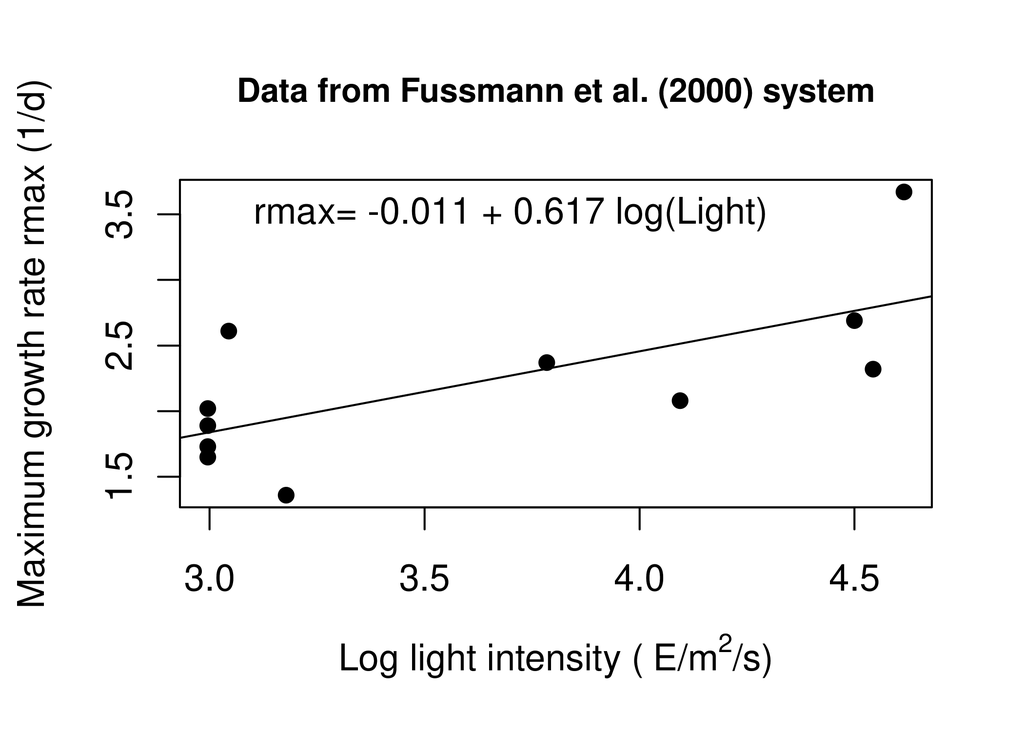

##### Exercise

Run `Intro2.R`, then enter the command `plot(fit)` in the console and follow the directions in the console. Figure out what just happened by entering `?plot.lm` to bring up the help page for the function `plot.lm()` that carries out a `plot()` command for an object produced by `lm()`. (This is one example of how **R** uses the fact that statistical analyses are stored as model objects. `fit` “knows” what kind of object it is (in this case an object of type `lm`), and so `plot(fit)` invokes a function that produces plots suitable for an `lm` object.) **Answer:** **R** produced a series of diagnostic plots exploring whether or not the fitted linear model is a suitable fit to the data. In each of the plots, the 3 most extreme points (the most likely candidates for “outliers”) have been identified according to their sequence in the data set.

The axes in plots are scaled automatically, but the outcome is not always ideal (e.g. if you want several graphs with exactly the same axes limits). You can control scaling using the `xlim` and `ylim` arguments in `plot`: `plot(x,y,xlim=c(x1,x2), [other stuff])` will draw the graph with the $x$-axis running from `x1` to `x2`, and using `ylim=c(y1,y2)` within the `plot()` command will do the same for the $y$-axis.

##### Exercise

Create a plot of growth rate versus light intensity with the $x$-axis running from 0 to 120, and the $y$-axis running from 1 to 4.

##### Exercise

Several graphs can be placed within a single figure by using the `par` function (short for “parameter”) to adjust the layout of the plot. For example the command `par(mfrow=c(m,n))` divides the plotting area into $m$ rows and $n$ columns. As a series of graphs is drawn, they are placed along the top row from left to right, then along the next row, and so on. `mfcol=c(m,n)` has the same effect except that successive graphs are drawn down the first column, then down the second column, and so on.

Save `Intro2.R` with a new name and modify the program as follows. Use `mfcol=c(2,1)` to create graphs of growth rate as a function of `Light`, and of `log(growth rate)` as a function of `log(Light)` in the same figure.  
Do the same again, using `mfcol=c(1,2)`.

##### Exercise

Use `?par` to read about other plot control parameters that can be set using `par()`. Then draw a $2 \times 2$ set of plots, each showing the line $y=5x+3$ with x running from 3 to 8, but with 4 different line styles and 4 different line colors.

##### Exercise

Modify one of your scripts so that at the very end it saves the plot to disk. You can accomplish this using the `dev.print()` function. Do `?dev.print` to read about this function. Note that you need to specify the `file` argument to write your graphics to a file; if you don’t, it will try and send it to a printer. Also note that many alternative formats are available via the `dev` argument.

# Looping in **R**

Very frequently, a computation involves iterating some procedure across a range of cases, and every computer language I’ve ever come across has one or more facilities for producing such *loops*. **R** is no exception, though judging by their code, many **R** programmers look down their noses at loops. The fact remains that, at some point in life, one simply has to write a `for` loop. Here, we’ll look at the looping constructs available in **R**.

## `for` loops

Execute the following code.

```r
phi <- 1
for (k in 1:100) {
  phi <- 1+1/phi
  print(c(k,phi))
}
```

What does it do? Sequentially, for each value of `k` between 1 and 100, `phi` is modified. More specifically, at the beginning of the `for` loop, a vector containing all the integers from 1 to 100 in order is created. Then, `k` is set to the first element in that vector, i.e., 1. Then the **R** expression from the `{` to the `}` is evaluated. When that expression has been evaluated, `k` is set to the next value in the vector. The process is repeated until, at the last evaluation, `k` has value 100.

As an aside, note that the final value of `phi` is the Golden Ratio, 1.618034.

As an example of a situation where a loop of some sort is really needed, suppose we wish to iterate the Beverton-Holt map (one of the simplest discrete-time models of population growth),
$$\begin{equation*}
N_{t+1} = \frac{a\,N_t}{1+b\,N_t}.
\end{equation*}$$
We simply have no option but to do the calculation one step at a time. Here’s an **R** code that does this

```r
a <- 1.1
b <- 0.001
T <- seq(from=1,to=200,by=1)
N <- numeric(length(T))
n <- 2
for (t in T) {
  n <- a*n/(1+b*n)
  N[t] <- n
}
```

Spend some time to make sure you understand what happens at each line of the above. We can plot the population sizes $N_t$ through time via

```r
plot(T,N)
```

**plot**

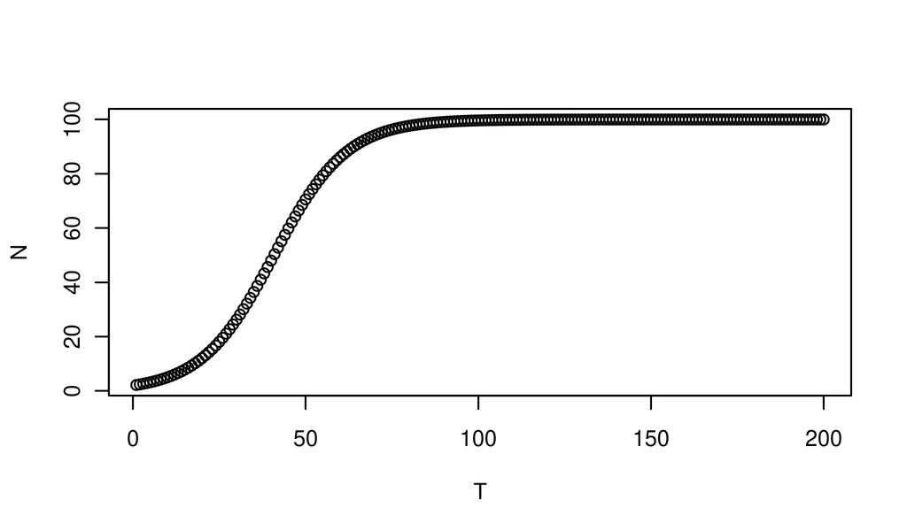

##### Gotcha:

An alternative way to do the above might be something like

```r
N <- numeric(length(T))
for (t in 1:length(T)) {
  n <- a*n/(1+b*n)
  N[t] <- n
}
```

##### Exercise

Check that this works with different vectors `T`. What happens when `T` has length 1? What happens when `T` has length 0? Why? To avoid this trap, it’s preferable to use `seq_len`, `seq_along`, or `seq.int` instead of the `1:n` construction used above. This and many other **R** gotchas are described in the useful [*R Inferno* (Burns 2012)](https://www.burns-stat.com/pages/Tutor/R_inferno.pdf).

## `while` loops

A second looping construct is the `while` loop. Using `while`, we can compute the Golden Ratio as before:

```r
phi <- 20
k <- 1
while (k <= 100) {
  phi <- 1+1/phi
  print(c(k,phi))
  k <- k+1
}
```

What’s going on here? First, `phi` and `k` are initialized. Then the `while` loop is started. At each iteration of the loop, `phi` is modified, and intermediate results printed, as before. In addition, `k` is incremented. The `while` loop continues to iterate until the condition `k <= 100` is no longer `TRUE`, at which point, the `while` loop terminates.

Note that here we’ve chosen a large number (100) of iterations. Perhaps we could get by with fewer. If we wanted to terminate the iterations as soon as the value of `phi` stopped changing, we could do:

```r
phi <- 20
conv <- FALSE
while (!conv) {
  phi.new <- 1+1/phi
  conv <- phi==phi.new
  phi <- phi.new
}
```

##### Exercise

Verify that the above works as intended. How many iterations are needed?

Another way to accomplish this would be to use `break` to stop the iteration when a condition is met. For example

```r
phi <- 20
while (TRUE) {
  phi.new <- 1+1/phi
  if (phi==phi.new) break
  phi <- phi.new
}
```

While this `while` loop is equivalent to the one before, it does have the drawback that, if the `break` condition is never met, the loop will go on indefinitely. An alternative that avoids this is to use a `for` loop with a large (but finite) number of iterations, together with `break`:

```r
phi <- 3
for (k in seq_len(1000)) {
  phi.new <- 1+1/phi
  if (phi==phi.new) break
  phi <- phi.new
}
```

##### Exercise

Recompute the trajectory of the Beverton-Holt model using a `while` loop. Verify that your answer is exactly equivalent to the one above.

## `repeat` loops

A third looping construct in **R** involves the `repeat` keyword. For example,

```r
phi <- 12
repeat {
  phi.new <- 1/(1+phi)
  if (phi==phi.new) break
  phi <- phi.new
}
```

In addition, **R** provides the `next` keyword, which, like `break`, is used in the body of a looping construct. Rather than terminating the iteration, however, it aborts the current iteration and leads to the immediate execution of the next iteration.

For more information on looping and other control-flow constructs, execute `?Control`.

# Functions and environments

## Definitions and examples

An extremely useful feature in **R** is the ability to write arbitrary *functions*. A function, in this context, is an algorithm that performs a specific computation that depends on inputs (the function’s *arguments*) and produces some output (the function’s *value*) and/or has some *side effects*. Let’s see how this is done.

Here is a function that squares a number.

```r
sq <- function (x) x^2
```

The syntax is `function (arglist) expr`. The one argument in this case is `x`. When a particular value of `x` is supplied, **R** performs the squaring operation. The function then *returns* the value `x^2`:

```r
sq(3); sq(9); sq(-2);
```

**output**

```
[1] 9
```

**output**

```
[1] 81
```

**output**

```
[1] 4
```

Here is a function with two arguments and a more complex *body*, as we call the expression that is evaluated when the function is called.

```r
f <- function (x, y = 3) {
  a <- sq(x)
  a+y
}
```

Here, the body is the **R** expression from `{` to `}`. Unless the `return` codeword is used elsewhere in the function body, the value returned is always the last expression evaluated. Thus:

```r
f(3,0); f(2,2); f(3);
```

**output**

```
[1] 9
```

**output**

```
[1] 6
```

**output**

```
[1] 12
```

Note that in the last case, only one argument was supplied. In this case, `y` assumed its default value, 3.

Note that functions need not be assigned to symbols; they can be *anonymous*:

```r
function (x) x^5
```

**output**

```
function (x) x^5
```

```r
(function (x) x^5)(2)
```

**output**

```
[1] 32
```

A function can also have side effects, e.g.,

```r
hat <- "hat"
hattrick <- function (y) {
  hat <<- "rabbit"
  2*y
}
hat; hattrick(5); hat
```

**output**

```
[1] "hat"
```

**output**

```
[1] 10
```

**output**

```
[1] "rabbit"
```

However, the very idea of a function insists that we should never experience *unintentional* side effects. We’ll see how **R** realizes this imperative below.

##### An aside

If we want the function not to automatically print, we can wrap the return value in `invisible()`:

```r
hattrick <- function (y) {
  hat <<- "rabbit"
  invisible(2*y)
}
hattrick(5)
print(hattrick(5))
```

**output**

```
[1] 10
```

A function in **R** is defined by three components:

- its *formal parameters*, i.e., its argument list,
- its body, and
- its *environment*, i.e., the context in which the function was defined.

**R** provides simple functions to interrogate these function components:

```r
formals(hattrick)
```

[output not shown]

```r
body(hattrick)
```

**output**

```
{
    hat <<- "rabbit"
    invisible(2 * y)
}
```

```r
environment(hattrick)
```

**output**

```
<environment: R_GlobalEnv>
```

## Function scope

**Note:** This section draws heavily, and sometimes verbatim, on §10.7 of the *Introduction to **R*** manual (R Core Team 2014a).

As noted above, a paramount consideration in the implementation of functions in any programming language is that unintentional side effects should never occur. In particular, I should be free to write a function that creates temporary variables as an aid to its computations, and be able to rest assured that no variables I create temporarily will interfere with any other variables I’ve defined anywhere else. To accomplish this, **R** has a specific set of *scoping rules*.

Consider the function

```r
f <- function (x) {
  y <- 2*x
  print(x)
  print(y)
  print(z)
}
```

In this function’s body, `x` is a formal parameter, `y` is a local variable, and `z` is a free, or *unbound* variable. When `f` is evaluated, each of these variables must be *bound* to some value. In **R** , the free variable bindings are resolved—each time the function is evaluated—by first looking in the environment where the function was created. This is called *lexical scope*. Thus if we execute

```r
f(3)
```

we get an error, because no object named `z` can be found. If, however, we do

```r
z <- 10
f(3)
```

**output**

```
[1] 3
[1] 6
[1] 10
```

we don’t get an error, because `z` is defined in the environment, `<environment: R_GlobalEnv>`, of `f`. Similarly, when we do

```r
z <- 13
g <- function (x) {
  2*x+z
}
f <- function (x) {
  z <- -100
  g(x)
}
f(5)
```

**output**

```
[1] 23
```

The relevant value of `z` is the one in the environment where `g` was *defined*, not the one in the environment wherein it is *called*.

## Nested functions and environments

In each of the following examples, make sure you understand exactly what has happened.

Consider this:

```r
y <- 11
f <- function (x) {
  y <- 2*x
  y+x
}
f(1); y
```

**output**

```
[1] 3
```

**output**

```
[1] 11
```

##### Exercise

Why hasn’t `y` changed its value?

What about this?

```r
y <- 0
f <- function (x) {
  2*x+y
}
f(1); y
```

**output**

```
[1] 2
```

**output**

```
[1] 0
```

##### Exercise

Why is the return value of `f` different?

How about the following?

```r
g <- function (y) y
f <- function (x) {
  g <- function (y) {
    2*y
  }
  11+g(x)
}
f(2); g(2)
```

**output**

```
[1] 15
```

**output**

```
[1] 2
```

##### Exercise

Be sure you understand what’s happening at each line and why you get the results you see.

Another example:

```r
y <- 11
f <- function (x) {
  y <- 22
  g <- function (x) {
    x+y
  }
  g(x)
}
f(1); y
```

**output**

```
[1] 23
```

**output**

```
[1] 11
```

##### Exercise

Which value of `y` was used?

Compare that with this:

```r
y <- 11
f <- function (x) {
  y <- 22
  g <- function (x) {
    y <<- 7
    x+y
  }
  c(g(x),y)
}
f(1); y
```

**output**

```
[1] 8 7
```

**output**

```
[1] 11
```

and this:

```r
y <- 11
f <- function (x) {
  g <- function (x) {
    x+y
  }
  g(x)
}
f(1); y
```

**output**

```
[1] 12
```

**output**

```
[1] 11
```

and this:

```r
f <- function (x) {
  y <- 37
  g <- function (x) {
    h <- function (x) {
      x+y
    }
    h(x)
  }
  g(x)
}
f(1); y
```

**output**

```
[1] 38
```

**output**

```
[1] 11
```

Finally, consider the following:

```r
rm(y)
f <- function (x) {
  g <- function (x) {
    y <<- 2*x
    y+1
  }
  g(x)+1
}
f(11); y
```

**output**

```
[1] 24
```

**output**

```
[1] 22
```

```r
f(-2); y
```

**output**

```
[1] -2
```

**output**

```
[1] -4
```

##### Exercise

In the above five code snippets, make sure you understand the differences.

As mentioned above, each function is associated with an environment: the environment within which it was defined. When a function is evaluated, a new temporary environment is created, within which the function’s calculations are performed. Every new environment has a parent, the environment wherein it was created. The parent of this new environment is the function’s environment. To see this, try

```r
f <- function () {
  g <- function () {
    h <- function () {
      cat("inside function h:\n")
      cat("current env: ")
      print(environment())
      cat("parent env: ")
      print(parent.frame(1))
      cat("grandparent env: ")
      print(parent.frame(2))
      cat("great-grandparent env: ")
      print(parent.frame(3))
      invisible(NULL)
    }
    cat("inside function g:\n")
    cat("environment of h: ")
    print(environment(h))
    cat("current env: ")
    print(environment())
    cat("parent env: ")
    print(parent.frame(1))
    cat("grandparent env: ")
    print(parent.frame(2))
    h()
  }
  cat("inside function f:\n")
  cat("environment of g: ")
  print(environment(g))
  cat("current env: ")
  print(environment())
  cat("parent env: ")
  print(parent.frame(1))
  g()
}
cat("environment of f: "); print(environment(f))
cat("global env: "); print(environment())
f()
```

**output**

```
environment of f: <environment: R_GlobalEnv>
global env: <environment: R_GlobalEnv>
inside function f:
environment of g: <environment: 0x55cfef96ed08>
current env: <environment: 0x55cfef96ed08>
parent env: <environment: R_GlobalEnv>
inside function g:
environment of h: <environment: 0x55cfe9c56ac8>
current env: <environment: 0x55cfe9c56ac8>
parent env: <environment: 0x55cfef96ed08>
grandparent env: <environment: R_GlobalEnv>
inside function h:
current env: <environment: 0x55cfe9b71038>
parent env: <environment: 0x55cfe9c56ac8>
grandparent env: <environment: 0x55cfef96ed08>
great-grandparent env: <environment: R_GlobalEnv>
```

Each variable referenced in the function’s body is bound, first, to a formal argument if possible. If a local variable of that name has previously been created (via one of the assignment operators `<-`, `->`, or `=`, this is the variable that is affected by any subsequent assignments. If the variable is neither a formal parameter nor a local variable, then the parent environment of the function is searched for that variable. If the variable has not been found in the parent environment, then the grand-parent environment is searched, and so on.

If the assignment operators `<<-` or `->>` are used, a more extensive search for the referenced assignee is made. If the variable does not exist in the local environment, the parent environment is searched. If it does not exist in the parent environment, then the grand-parent environment is searched, and so on. Finally, if the variable cannot be found anywhere along the lineage of environments, a new global variable is created, with the assigned value.

# The `apply` family of functions

As mentioned above, there are circumstances under which looping constructs are really necessary. Very often, however, we wish to perform some operation across all the elements of a vector, array, or dataset. In such cases, it is faster and more elegant (to the **R** afficiando’s eye) to use the `apply` family of functions.

## List apply: `lapply`

`lapply` applies a function to each element of a list or vector, returning a list.

```r
x <- list("teenage","mutant","ninja","turtle",
          "hamster","plumber","pickle","baby")
lapply(x,nchar)
```

**output**

```
[[1]]
[1] 7

[[2]]
[1] 6

[[3]]
[1] 5

[[4]]
[1] 6

[[5]]
[1] 7

[[6]]
[1] 7

[[7]]
[1] 6

[[8]]
[1] 4
```

```r
y <- c("teenage","mutant","ninja","turtle",
       "hamster","plumber","pickle","baby")
lapply(y,nchar)
```

**output**

```
[[1]]
[1] 7

[[2]]
[1] 6

[[3]]
[1] 5

[[4]]
[1] 6

[[5]]
[1] 7

[[6]]
[1] 7

[[7]]
[1] 6

[[8]]
[1] 4
```

## Sloppy list apply: `sapply`

`sapply` isn’t content to always return a list: it attempts to simplify the results into a non-list vector if possible.

```r
x <- list("pizza","monster","jigsaw","puddle",
          "hamster","plumber","pickle","baby")
sapply(x,nchar)
```

**output**

```
[1] 5 7 6 6 7 7 6 4
```

```r
y <- c("pizza","monster","jigsaw","puddle",
       "hamster","plumber","pickle","baby")
sapply(y,nchar)
```

**output**

```
  pizza monster  jigsaw  puddle hamster plumber  pickle
      5       7       6       6       7       7       6
   baby
      4
```

## Multiple-list apply: `mapply`

`mapply` is a multiple-argument version of `sapply`:

```r
x <- c("pizza","monster","jigsaw","puddle")
y <- c("cowboy","barbie","slumber","party")
mapply(paste,x,y,sep="/")
```

**output**

```
           pizza          monster           jigsaw
  "pizza/cowboy" "monster/barbie" "jigsaw/slumber"
          puddle
  "puddle/party"
```

As usual, the recycling rule applies:

```r
mapply(paste,x,y[2:3])
```

**output**

```
            pizza           monster            jigsaw
   "pizza barbie" "monster slumber"   "jigsaw barbie"
           puddle
 "puddle slumber"
```

```r
mapply(paste,x[c(1,3)],y)
```

**output**

```
          pizza          jigsaw            <NA>
 "pizza cowboy" "jigsaw barbie" "pizza slumber"
           <NA>
 "jigsaw party"
```

## Array apply: `apply`

`apply` is very powerful and a bit more complex. It allows an arbitrary function to applied to each slice of an array, where the slices can be defined in all possible ways. Let’s create a matrix:

```r
A <- array(data=seq_len(15),dim=c(3,5)); A
```

**output**

```
     [,1] [,2] [,3] [,4] [,5]
[1,]    1    4    7   10   13
[2,]    2    5    8   11   14
[3,]    3    6    9   12   15
```

To apply an operation to each row, we *marginalize* over the first dimension (rows). For example, to sum the rows, we’d do

```r
apply(A,1,sum)
```

**output**

```
[1] 35 40 45
```

To sum the columns (the second dimension), we’d do

```r
apply(A,2,sum)
```

**output**

```
[1]  6 15 24 33 42
```

Now suppose we have a 3-dimensional array:

```r
A <- array(data=seq_len(30),dim=c(3,5,2)); A
```

**output**

```
, , 1

     [,1] [,2] [,3] [,4] [,5]
[1,]    1    4    7   10   13
[2,]    2    5    8   11   14
[3,]    3    6    9   12   15

, , 2

     [,1] [,2] [,3] [,4] [,5]
[1,]   16   19   22   25   28
[2,]   17   20   23   26   29
[3,]   18   21   24   27   30
```

To sum the rows within each slice, we’d do

```r
apply(A,c(1,3),sum)
```

**output**

```
     [,1] [,2]
[1,]   35  110
[2,]   40  115
[3,]   45  120
```

while to sum the slices, we’d do

```r
apply(A,3,sum)
```

**output**

```
[1] 120 345
```

For each of the above, make sure you understand exactly what has happened.

Of course, we can apply an anonymous function wherever we apply a named function:

```r
apply(A,c(2,3),function (x) sd(x)/sqrt(length(x)))
```

**output**

```
          [,1]      [,2]
[1,] 0.5773503 0.5773503
[2,] 0.5773503 0.5773503
[3,] 0.5773503 0.5773503
[4,] 0.5773503 0.5773503
[5,] 0.5773503 0.5773503
```

If any additional arguments are given to `apply`, these are passed to the function. For example, make sure you understand what is happening in the lines:

```r
apply(A,c(1,2),function (x, y) sum(x>y),y=8)
```

**output**

```
     [,1] [,2] [,3] [,4] [,5]
[1,]    1    1    1    2    2
[2,]    1    1    1    2    2
[3,]    1    1    2    2    2
```

```r
apply(A,c(1,2),function (x, y) sum(x>y),y=-1)
```

**output**

```
     [,1] [,2] [,3] [,4] [,5]
[1,]    2    2    2    2    2
[2,]    2    2    2    2    2
[3,]    2    2    2    2    2
```

## Table apply: `tapply`

`tapply` is, in a way, an extension of `table`. The syntax is `tapply(X,INDEX,FUN,...)`, where `X` is a vector, `INDEX` is a list of one or more factors, each the same length as `X`, and `FUN` is a function. The vector `X` will be split into subvectors according to `INDEX`, and `FUN` will be applied to each of the subvectors. By default, the result is simplified into an array if possible. Some examples:

```r
x <- seq(1,30,by=1)
b <- rep(letters[1:10],times=3)
data.frame(x,b)
```

**output**

```
  x b
  1 a
  2 b
  3 c
  4 d
  5 e
  6 f
  7 g
  8 h
  9 i
 10 j
 11 a
 12 b
 13 c
 14 d
```

[output cut: 16 more lines]

```r
tapply(x,b,sum)
```

**output**

```
 a  b  c  d  e  f  g  h  i  j
33 36 39 42 45 48 51 54 57 60
```

```r
b <- rep(letters[1:10],each=3)
data.frame(x,b)
```

**output**

```
  x b
  1 a
  2 a
  3 a
  4 b
  5 b
  6 b
  7 c
  8 c
  9 c
 10 d
 11 d
 12 d
 13 e
 14 e
```

[output cut: 16 more lines]

```r
tapply(x,b,sum)
```

**output**

```
 a  b  c  d  e  f  g  h  i  j
 6 15 24 33 42 51 60 69 78 87
```

The following uses the seed predation data described by Bolker (2008).

```r
datafile <- "https://kingaa.github.io/R_Tutorial/data/seedpred.dat"
seeds <- read.table(datafile,header=TRUE,
                    colClasses=c(station='factor',dist='factor',date='Date'))
x <- subset(seeds,available>0)
with(x, tapply(tcum,list(dist,station),max,na.rm=TRUE))
```

**output**

```
    1  10 100 101 102 103 104 105 106 107 108 109 11 110
10 24 248 122 248  10  17  39  17  46  10   3  17 NA  10
25 18 123  11 249 249  11  11 249  81  11 123 249  4  25
   111 112 113 114 115 116 117 118 119  12 120 121 122 123
10  10  17 248 248  67 248 248  24  10 248  17 248 248   3
25 249  47 249 249  40  68  11  32  18 249  32  11 249  68
   124 125 126 127 128 129  13 130 131 132 133 134 135 136
10 248 248  10  67  17 248 248 248   3 248 248  10  10   3
25 249 249  18  NA  18 249 249  18  18  40  54  18   4  40
   137 138 139 14 140 141 142 143 144 145 146 147 148 149
10 248 248   3 24 248 248 248 248 248 248 248  24 248 248
25  61 249   4 61 249  68  11  NA   4 249 209   4 249  81
   15 150 151 152 153 154 155 156 157 158 159  16 160  17
10  3 248  39 248 248 248  NA  53 248 248  53 248  NA 248
25 11 249 249 249 249 249 249 123 249 249  32  25 249   4
```

[output cut: 18 more lines]

## sapply with expected result: `vapply`

When we could use `sapply` and we know exactly what the size and class of the value of the function will be, it is sometimes faster to use `vapply`. The syntax is like that of `sapply`: `vapply(X,FUN,FUN.VALUE,...)`, where `X` and `FUN` are as in `sapply`, but we specify the size and class of the value of `FUN` via the `FUN.VALUE` argument. For example, suppose we define a function that, given a number between 1 and 26 will return the corresponding letter of the alphabet:

```r
alph <- function (x) {
  stopifnot(x >= 1 && x <= 26)
  LETTERS[as.integer(x)]
}
```

This function will return a vector of length 1 and class `character`. To apply it to a randomly sampled set of integers, we might do

```r
x <- sample(1:26,50,replace=TRUE)
y <- vapply(x,alph,character(1))
paste(y,collapse="")
```

**output**

```
[1] "ORIFWKBWAMEJBZUMLKRJVEOIKQXEYRNTGAXXXUVQTZIHQGANTI"
```

# Vectorized functions vs loops

As Ligges and Fox (2008) point out, the idea that one should avoid loops wherever possible in **R**, using instead vectorized functions like those in the `apply` family, is quite widespread in some quarters. The belief, which probably dates back to infelicities in early versions of **S** and **Splus** but is remarkably persistent, is that loops are very slow in **R**. Let’s have a critical look at this.

Consider the following loop code that can be vectorized:

```r
x <- runif(n=1e6,min=0,max=2*pi)
y <- numeric(length(x))
for (k in seq_along(x)) {
  y[k] <- sin(x[k])
}
```

To time this, we can wrap the vectorizable parts in a call to `system.time`:

```r
x <- runif(n=1e6,min=0,max=2*pi)
system.time({
  y <- numeric(length(x))
  for (k in seq_along(x)) {
    y[k] <- sin(x[k])
  }
})
```

**output**

```
   user  system elapsed
  0.090   0.001   0.092
```

We can compare this with a simple call to `sin` (which is vectorized):

```r
system.time(z <- sin(x))
```

**output**

```
   user  system elapsed
  0.013   0.008   0.022
```

Clearly, calling `sin` directly is much faster. What about using `sapply`?

##### Exercise

Compare the time spent on the equivalent calculation, using `sapply`. What does this result tell you about where the computational cost is incurred?

The above example is very simple in that there is a builtin function (`sin` in this case) which is capable of the fully vectorized computation. In such a case, it is clearly preferable to use it. Frequently, however, no such builtin function exists, i.e., we have a custom function of our own we want to apply to a set of data. Let’s compare the relative speeds of loops and `sapply` in this case.

```r
x <- seq.int(from=20,to=1e6,by=10)
f <- function (x) {
  (((x+1)*x+1)*x+1)*x+1
}
system.time({
  res1 <- numeric(length(x))
  for (k in seq_along(x)) {
    res1[k] <- f(x[k])
  }
})
```

**output**

```
   user  system elapsed
  0.066   0.000   0.067
```

```r
system.time(res2 <- sapply(x,f))
```

**output**

```
   user  system elapsed
  0.065   0.000   0.065
```

[Actually, in this case, `f` is vectorized automatically. Why is this?]

```r
system.time(f(x))
```

**output**

```
   user  system elapsed
  0.001   0.000   0.001
```

Another example: in this case function `g` is not vectorized.

```r
g <- function (x) {
  if ((x[1] > 30) && (x[1] < 5000)) 1 else 0
}

system.time({
  res1 <- numeric(length(x))
  for (k in seq_along(x)) {
    res1[k] <- g(x[k])
  }
})
```

**output**

```
   user  system elapsed
  0.065   0.000   0.064
```

```r
system.time(res2 <- sapply(x,g))
```

**output**

```
   user  system elapsed
  0.067   0.000   0.067
```

# Acknowledgments

These notes are based in part on materials used in the series of NSF-funded workshops taught in association with the Ecology and Evolution of Infectious Diseases conference. Instructors there included Ben Bolker, Ottar Bjørnstad, Steve Ellner, and Stu Field. Steve Ellner contributed the document that formed the early skeleton of these notes; he based them in turn on course materials by Colleen Webb, Jonathan Rowell, and Daniel Fink at Cornell, Professors Lou Gross (University of Tennessee) and Paul Fackler (NC State University), and on the book *Getting Started with Matlab* by Rudra Pratap (Oxford University Press). The document also draws on the documentation supplied with **R**, including the *Introduction to **R*** manual. Versions of this document have been used in courses taught by BB and AAK at Florida and Michigan, at workshops run under the auspices of the International Centre for Theoretical Physics in Trieste, and elsewhere.

# References

Bolker BM (2008). *Ecological Models and Data in R*. Princeton University Press. Retrieved from http://ms.mcmaster.ca/~bolker/emdbook/

Burns P (2012). *The R Inferno* 2nd ed. http://www.burns-stat.com/. Retrieved from http://www.burns-stat.com/pages/Tutor/R_inferno.pdf

Chambers JM (1998). *Programming with Data*. Springer, New York. Retrieved from http://cm.bell-labs.com/cm/ms/departments/sia/Sbook/

Fussman GF, Ellner SP, Sherzer KW, Nelson G. Hairston J (2000). “Crossing the Hopf Bifurcation in a Live Predator-Prey System.” *Science*, **290**, 1358–60.

Ihaka R, Gentleman R (1996). “R: A Language for Data Analysis and Graphics.” *Journal of Computational and Graphical Statistics*, **5**, 299–314.

Ligges U, Fox J (2008). “R Help Desk : How Can I Avoid This Loop or Make It Faster?” *R News*, **8**(1), 46–50. Retrieved from http://www.r-project.org/doc/Rnews/Rnews_2008-1.pdf

R Core Team (2014a). *An Introduction to R*. Retrieved from http://cran.r-project.org/doc/manuals/r-release/R-intro.html

R Core Team (2014b). *R: A Language and Environment for Statistical Computing*. R Foundation for Statistical Computing, Vienna, Austria. Retrieved from http://www.R-project.org/

Stevens SS (1946). “On the Theory of Scales of Measurement.” *Science*, **103**(2684), 677–680. https://doi.org/10.1126/science.103.2684.677.

Venables WN, Ripley BD (2002). *Modern Applied Statistics with S. Fourth Edition*. Springer, New York. Retrieved from http://www.stats.ox.ac.uk/pub/MASS4/

Licensed under the [Creative Commons Attribution-NonCommercial license](http://creativecommons.org/licenses/by-nc/4.0/). Please share and remix noncommercially, mentioning its origin.